# Lithuania metabarcoding

Kristina Kuprina

2025-01-03

```r
library("phyloseq")
library("vegan")
library("DESeq2")
library("ggplot2")
library("dendextend")
library("tidyr")
library("viridis")
library("reshape")
library("metacoder")
library("dplyr")
library('readr')
library('stringr')
library('agricolae')
library('ape')
library('ggrepel')
library("RColorBrewer")
library('rstatix')
library('microeco')
library('ggalluvial')
library('iNEXT')
library('ggvenn')
```

### Reading the data

```r
#reading the data
count_tab <-read.table("Raw_Counts.txt", header=T, row.names=1, check.names=F)
sample_info <- read.table("Sample_Info.txt", header=T, row.names=1, check.names=F)

tax_tab<- read.delim("Taxonomy.txt")
tax_tab$OTU[duplicated(tax_tab$OTU)] # check for duplicated OTUs
```

```
## character(0)
```

```r
count_tab <- count_tab[rownames(count_tab) %in% tax_tab$OTU, ]
```

### Treatment of NTC

```r
# sum of NTC counts for each OTU
NTC <-rowSums(count_tab[, 1:6])

# sum of sample counts for each OTU
sample_counts <- rowSums(count_tab[, 7:90])

# normalize sample counts by dividing the samples' total by 12 – as there are 12 as many samples (84) as there are NTCs (6) (84/6=14)
norm_sample_OTU_counts <- sample_counts/14

# which OTUs are deemed likely contaminants based on the threshold noted above:
blank_OTUs <- names(NTC[NTC * 2  > norm_sample_OTU_counts]) # OTUs which have more counts than 1/2 of the sample counts
length(blank_OTUs) # this approach identified  4 out of ~283 OTUs that are likely to have originated from contamination
```

```
## [1] 4
```

```r
# looking at the percentage of reads retained for each sample after removing these presumed contaminant OTUs
colSums(count_tab[!rownames(count_tab) %in% blank_OTUs, ]) / colSums(count_tab) * 100
```

```
##       NTC       NTC       NTC       NTC       NTC       NTC        P2       D26
##  47.33096 100.00000  42.47967 100.00000 100.00000  49.33333 100.00000  99.99846
##       P27        P6        D6        V6        S6        V4        P9       S22
## 100.00000 100.00000 100.00000 100.00000 100.00000 100.00000 100.00000 100.00000
##        D2      P30A        V9       S13      S30A        D9       D13       V13
## 100.00000 100.00000 100.00000  99.99891  99.99435 100.00000 100.00000 100.00000
##       V23       V17       V16       D16       S17       P22       P17       D17
## 100.00000 100.00000 100.00000 100.00000 100.00000  99.99788 100.00000  99.99230
##        S9       P10       D22        S4        P5       P23       D23        V2
## 100.00000 100.00000 100.00000 100.00000 100.00000 100.00000  99.99784 100.00000
##      V2_3      S2_2       D24       V24        V5       S24       P26       S31
## 100.00000  99.99878 100.00000 100.00000 100.00000 100.00000 100.00000  99.99889
##       S27        S2       V27       S26       V10      V2_2      V30B       V78
## 100.00000 100.00000 100.00000 100.00000  99.95886 100.00000 100.00000 100.00000
##      V30A       P16      D30B       S10      D30A       S78       D31       P13
## 100.00000 100.00000 100.00000 100.00000  99.99615 100.00000 100.00000 100.00000
##        D4        D5       P76       D76       V76      S30B       P31       D78
##  99.99815 100.00000 100.00000 100.00000 100.00000  99.99704 100.00000 100.00000
##       S76       P78        P4      P2_2      P2_3      D2_2       D27       S23
##  99.99370 100.00000 100.00000 100.00000 100.00000  99.99735 100.00000 100.00000
##       P24      S2_3       V31      P30B       V26       V22       D10       S16
## 100.00000 100.00000 100.00000 100.00000 100.00000  99.97795  99.99355  99.99753
##      D2_3        S5
##  99.99515 100.00000
```

```r
filt_count_tab <- count_tab[!rownames(count_tab) %in% blank_OTUs, -c(1:6)] # removing blank_OTUs and the blank samples from further analysis
filt_count_tab <- filt_count_tab[rowSums(filt_count_tab == 0) != ncol(filt_count_tab), ] # delete OTUs with 0 counts -> 278 OTUs left
```

### Normalizing counts for sampling depth (variance stabilizing transformation in DEseq2 package)

```r
#reorder the row and column names
sample_info<-sample_info[order(rownames(sample_info)), ]
filt_count_tab<- filt_count_tab[,order(names(filt_count_tab))]

#add 1 to every count, so it is possible to calculate the geometric mean later
filt_count_tab1 <- filt_count_tab + 1

# create a DESeq2 object
deseq_counts <- DESeqDataSetFromMatrix(filt_count_tab1, colData = sample_info, design = ~Species)
deseq_counts_vst <- varianceStabilizingTransformation(deseq_counts, fitType='local')

#save as a matrix
vst_trans_count_tab <- assay(deseq_counts_vst)

#transform lowest values (absent counts) to 0
vst_trans_count_tab <- sweep(vst_trans_count_tab, 2, apply(vst_trans_count_tab, 2, min), "-")
```

### Add colors specific to species to the sample info table

```r
sample_info$color[sample_info$Species == "Pinus"] <- "dodgerblue3"
sample_info$color[sample_info$Species == "Diphasiastrum"] <- "darkorange1"
sample_info$color[sample_info$Species == "Vaccinium"] <- "purple4"
sample_info$color[sample_info$Species == "Soil"] <- "hotpink2"

sample_info_no_rep <- read.table("Sample_Info_noR.txt",header=T, row.names=1, check.names=F)
sample_info_no_rep<-sample_info_no_rep[order(rownames(sample_info_no_rep)), ]
sample_info_no_rep$color[sample_info_no_rep$Species == "Pinus"] <- "dodgerblue3"
sample_info_no_rep$color[sample_info_no_rep$Species == "Diphasiastrum"] <- "darkorange1"
sample_info_no_rep$color[sample_info_no_rep$Species == "Vaccinium"] <- "purple4"
sample_info_no_rep$color[sample_info_no_rep$Species == "Soil"] <- "hotpink2"
```

### Venn diagram: presence of OTUs in the sample type

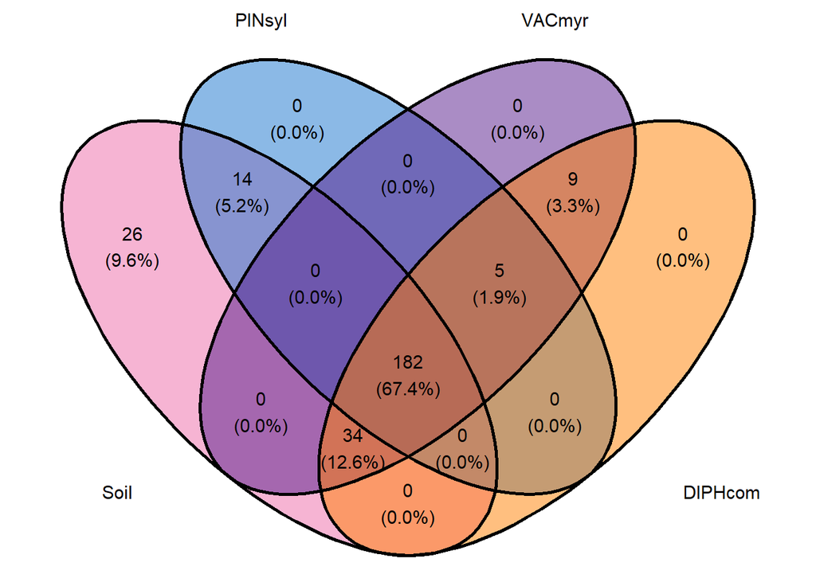

```r
#remove technical replicates:
Venn_OTU <- as.data.frame(vst_trans_count_tab)
Venn_OTU <- (Venn_OTU[, !grepl("_", colnames(Venn_OTU))])

Venn_S <- grepl("S", names(Venn_OTU))
OTU_S <- rownames(Venn_OTU)[rowSums(Venn_OTU[, Venn_S]) != 0]

Venn_P <- grepl("P", names(Venn_OTU))
OTU_P <- rownames(Venn_OTU)[rowSums(Venn_OTU[, Venn_P]) != 0]

Venn_V <- grepl("V", names(Venn_OTU))
OTU_V <- rownames(Venn_OTU)[rowSums(Venn_OTU[, Venn_V]) != 0]

Venn_D <- grepl("D", names(Venn_OTU))
OTU_D <- rownames(Venn_OTU)[rowSums(Venn_OTU[, Venn_V]) != 0]


venn <- list("Soil" = OTU_S, "PINsyl" = OTU_P, "VACmyr" = OTU_V, "DIPHcom" = OTU_D)

ggvenn(venn, fill_color = c("hotpink2", "dodgerblue3","purple4","darkorange1"),set_name_size = 4)
```

```r
#write the table to use it in jvenn tool: https://jvenn.toulouse.inrae.fr/app/index.html
#max_length <- max(length(OTU_S), length(OTU_P), length(OTU_V), length(OTU_D))
#OTU_S <- c(OTU_S, rep(NA, max_length - length(OTU_S)))
#OTU_P <- c(OTU_P, rep(NA, max_length - length(OTU_P)))
#OTU_V <- c(OTU_V, rep(NA, max_length - length(OTU_V)))
#OTU_D <- c(OTU_D, rep(NA, max_length - length(OTU_D)))
#Venn_df <- data.frame(OTU_S, OTU_P, OTU_V, OTU_D)

#write_tsv(Venn_df, "venn")
```

## Ordination Plots with package phyloseq (https://joey711.github.io/phyloseq/index.html)

### PCoA: all OTUs, with technical replicates

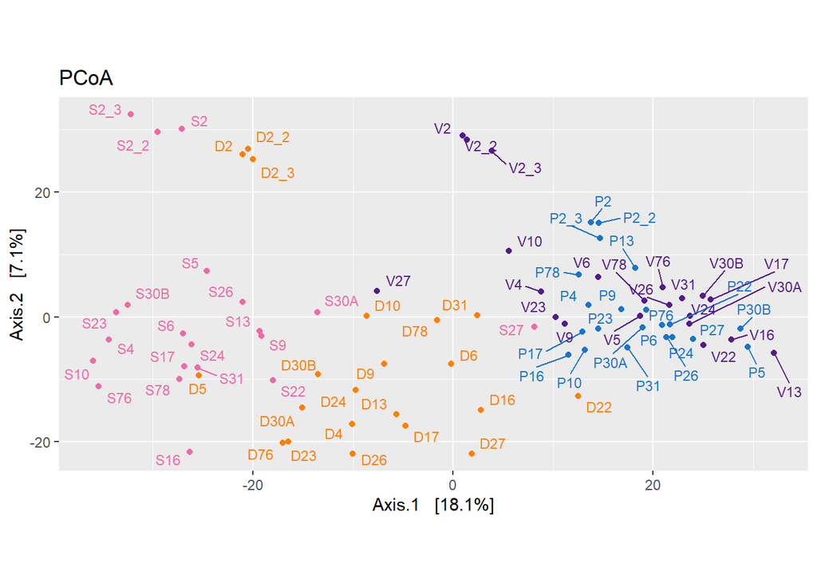

```r
# create phyloseq object with normalized data
vst_count_phy <- otu_table(vst_trans_count_tab, taxa_are_rows=T)
sample_info_tab_phy <- sample_data(sample_info)
vst_physeq <- phyloseq(vst_count_phy, sample_info_tab_phy)

#generating and visualizing the PCoA with phyloseq
vst_pcoa <- ordinate(vst_physeq, method="PCoA", distance="euclidean")
eigen_vals <- vst_pcoa$values$Eigenvalues # allows us to scale the axes according to their magnitude of separating apart the samples

pca<-plot_ordination(vst_physeq, vst_pcoa, color="Species") +
  labs(col="Species") + geom_point(size=1) +
  geom_text_repel(aes(label=rownames(sample_info)), size =3, force = 5, max.overlaps = 50) +
  coord_fixed(sqrt(eigen_vals[2]/eigen_vals[1])) + ggtitle("PCoA") +
  scale_color_manual(values=unique(sample_info$color[order(sample_info$Species)])) +
  theme(legend.position="none")
pca
```

Samples labelled as “S2”, “S2_2” and “S2_3” - three technical replicates of the soil sample S2. Same for D2, P2 and V2.

### PCoA - all OTUs, without technical replicates

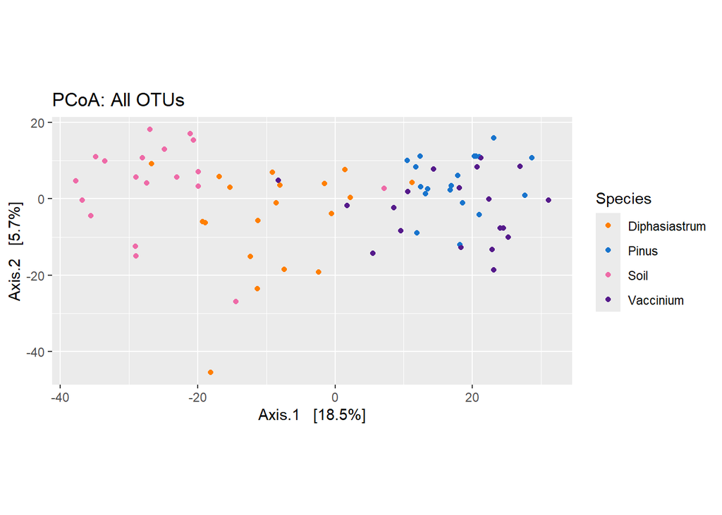

```r
# create phyloseq object with normalized data
vst_count_phy <- otu_table(vst_trans_count_tab, taxa_are_rows=T) #count data
sample_info_tab_phy <- sample_data(sample_info_no_rep) # sample data

tax_tab_physeq_all <- tax_tab[tax_tab$OTU %in% rownames(vst_trans_count_tab), ]
tax_tab_physeq_matrix <- as.matrix(tax_tab_physeq_all[, c("OTU", "Phylum", "Class", "Order")])
rownames(tax_tab_physeq_matrix) <- tax_tab_physeq_all[[1]]
tax_matrix<- tax_table(tax_tab_physeq_matrix) # OTU data
vst_physeq <- merge_phyloseq(vst_count_phy, sample_info_tab_phy, tax_matrix)

#generating and visualizing the PCoA
vst_pcoa <- ordinate(vst_physeq, method="PCoA", distance = "euclidean")
eigen_vals <- vst_pcoa$values$Eigenvalues

pcoa<-plot_ordination(vst_physeq, vst_pcoa, color="Species") +
  labs(col="Species") + geom_point(size=1) +
  coord_fixed(sqrt(eigen_vals[2]/eigen_vals[1])) + ggtitle("PCoA: All OTUs") +
  scale_color_manual(values=unique(sample_info_no_rep$color[order(sample_info_no_rep$Species)]))
pcoa
```

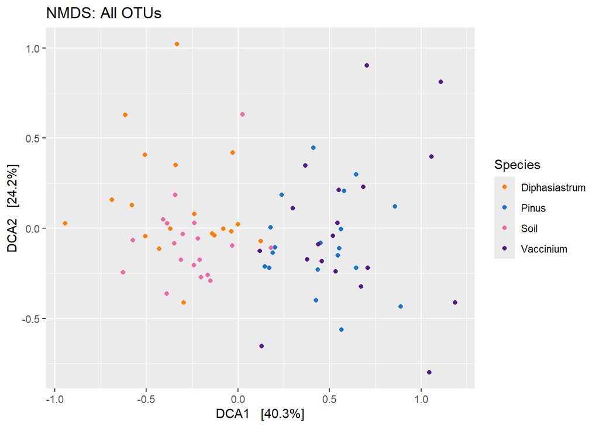

```r
vst_pcoa <- ordinate(vst_physeq, distance = "bray")

nmds<- plot_ordination(vst_physeq, vst_pcoa, color="Species", title="NMDS: All OTUs", type ="sample") +
  scale_color_manual(values=unique(sample_info_no_rep$color[order(sample_info_no_rep$Species)]))
nmds
```

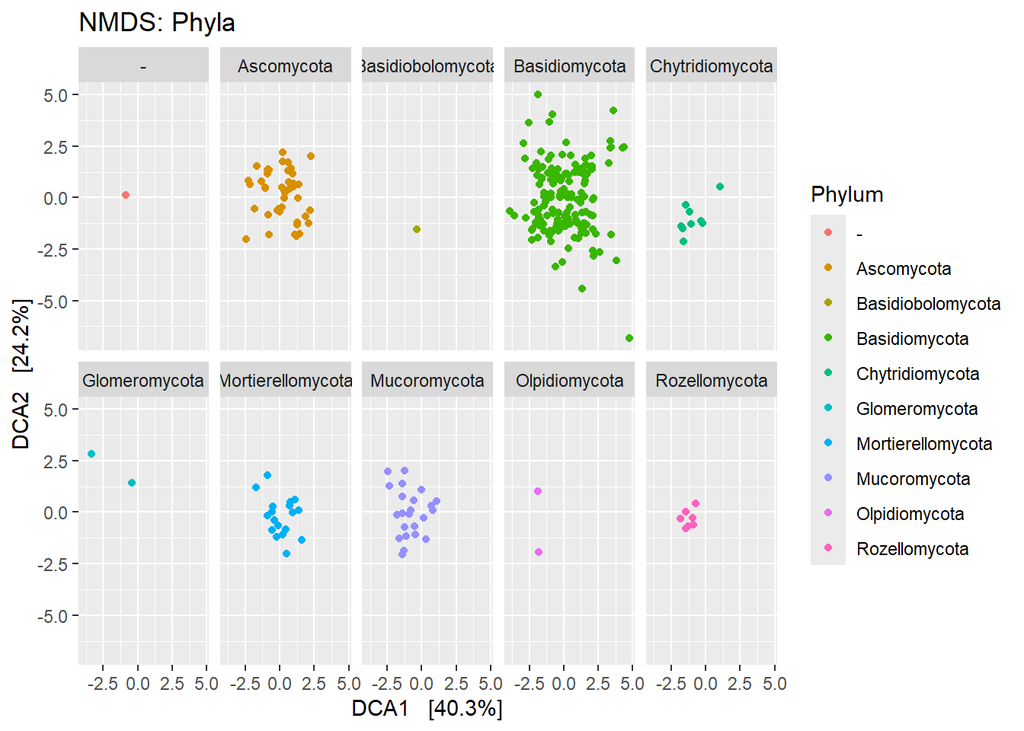

```r
p <-plot_ordination(vst_physeq, vst_pcoa, color="Phylum", title="NMDS: Phyla", type ="taxa")
p + facet_wrap(~Phylum, 2)
```

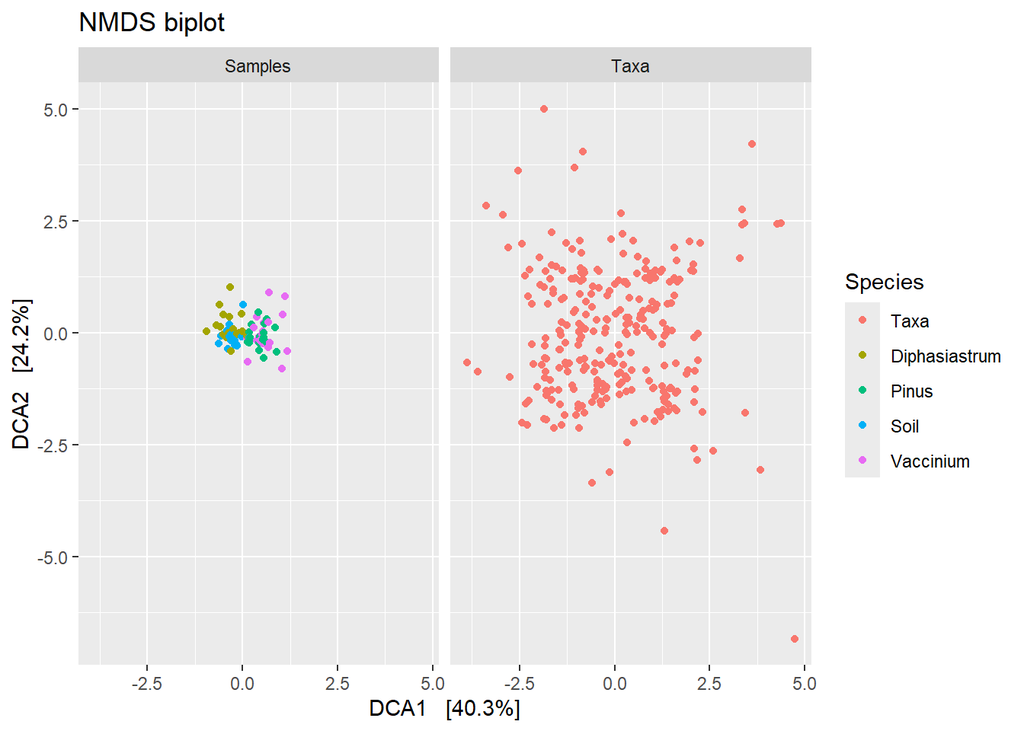

```r
p <-plot_ordination(vst_physeq, vst_pcoa, color="Species", title="NMDS biplot", type ="split")
p
```

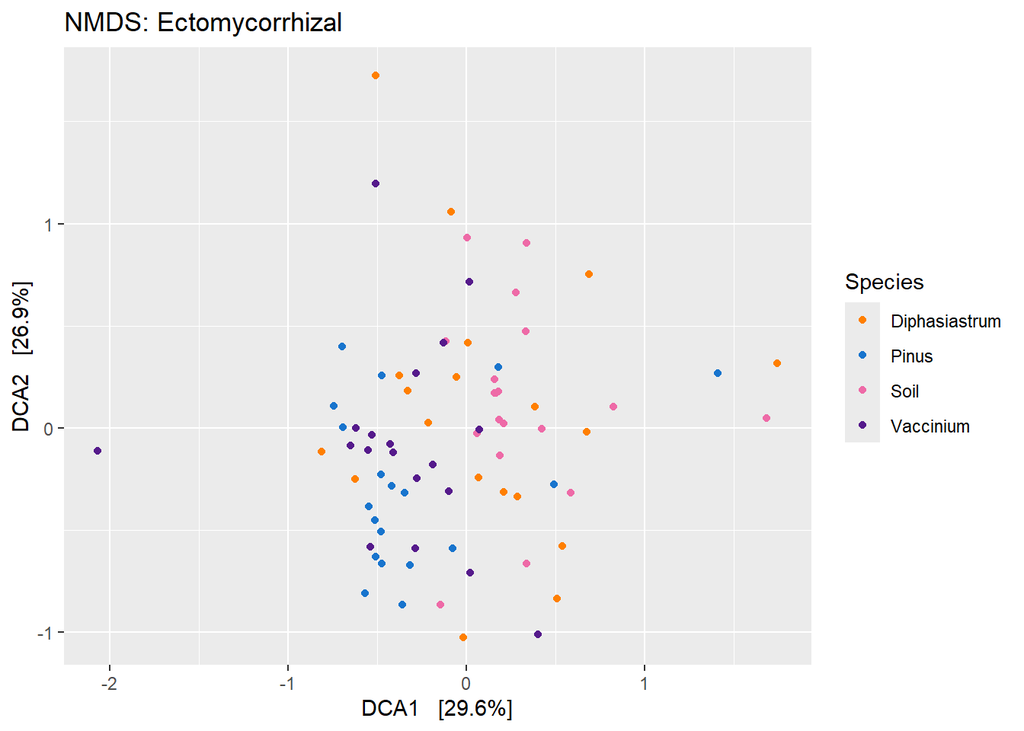

```r
# select only ECM OTUs:
ECM_OTUs <- tax_tab_physeq_all$OTU[tax_tab_physeq_all$Guild %in% c("Ectomycorrhizal")]
ECM_vst_trans_count_tab <- vst_trans_count_tab[ECM_OTUs, ]


vst_count_phy <- otu_table(ECM_vst_trans_count_tab, taxa_are_rows=T)
sample_info_tab_phy <- sample_data(sample_info_no_rep)

vst_physeq <- merge_phyloseq(vst_count_phy, sample_info_tab_phy)

#generating and visualizing the PCoA with phyloseq
vst_pcoa <- ordinate(vst_physeq, distance = "bray")

nmds_ECM<-plot_ordination(vst_physeq, vst_pcoa, color="Species", title="NMDS: Ectomycorrhizal", type = "sample")+
  scale_color_manual(values=unique(sample_info_no_rep$color[order(sample_info_no_rep$Species)]))
nmds_ECM
```

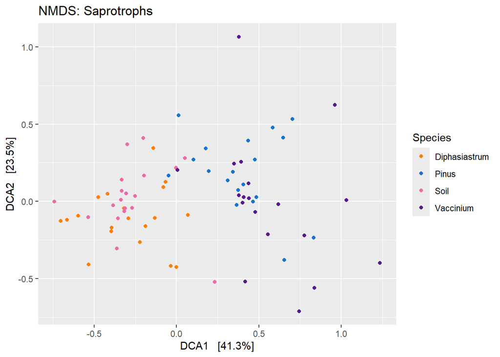

```r
# select only Saprotrophic OTUs:
Sapro_OTUs <- tax_tab_physeq_all$OTU[tax_tab_physeq_all$Guild %in% c("Saprotroph")]
Sapro_vst_trans_count_tab <- vst_trans_count_tab[Sapro_OTUs, ]

vst_count_phy <- otu_table(Sapro_vst_trans_count_tab, taxa_are_rows=T)
sample_info_tab_phy <- sample_data(sample_info_no_rep)

vst_physeq <- merge_phyloseq(vst_count_phy, sample_info_tab_phy)

#generating and visualizing the PCoA with phyloseq
vst_pcoa <- ordinate(vst_physeq, distance = "bray")

nmds_Sapro<-plot_ordination(vst_physeq, vst_pcoa, color="Species", title="NMDS: Saprotrophs", type = "sample")+
  scale_color_manual(values=unique(sample_info_no_rep$color[order(sample_info_no_rep$Species)]))
nmds_Sapro
```

# Taxonomic summaries

### Phylum

```r
#read info table with the samples without replicates
sample_info_no_rep <- read.table("Sample_Info_noR.txt", header=T, row.names=1, check.names=F)

tax_table<-tax_tab
row.names(tax_table) <- tax_table$OTU
tax_table <- tax_table[, -1]
tax_table<- tax_table[order(rownames(tax_table)),]

counts_norm_df<-as.data.frame(vst_trans_count_tab)

# create microeco file
meco_fungi <- microtable$new(sample_table = sample_info_no_rep, otu_table = counts_norm_df, tax_table = tax_table)

# color palette
mycol <- c("#A6CEE3" ,"#1F78B4" ,"#B2DF8A" ,"#33A02C" ,"#FB9A99", "#E31A1C" ,"#FDBF6F" ,"#FF7F00" ,"#CAB2D6" ,"#6A3D9A" ,"#FFFF99" ,"#B15928" , "#6fdc8c", "green4", "#004144")

t1 <- trans_abund$new(dataset = meco_fungi, taxrank = "Phylum", ntaxa = 15, groupmean = "Species")
```

```
## No taxa_abund list found. Calculate relative abundance with cal_abund function ...
```

```
## The result is stored in object$taxa_abund ...
```

```
## Species column is used to calculate mean abundance ...
```

```
## The transformed abundance data is stored in object$data_abund ...
```

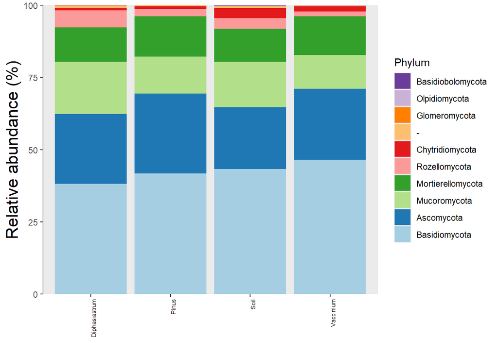

```r
Phylum <- t1$plot_bar(bar_full = FALSE, xtext_keep = TRUE, xtext_angle = 90,xtext_size = 6, color_values = mycol)
Phylum
```

“-” = not determined

### Per sample type: Order (15 most abundant)

```r
t1 <- trans_abund$new(dataset = meco_fungi, taxrank = "Order", ntaxa = 15,  groupmean = "Species")
```

```
## Species column is used to calculate mean abundance ...
```

```
## The transformed abundance data is stored in object$data_abund ...
```

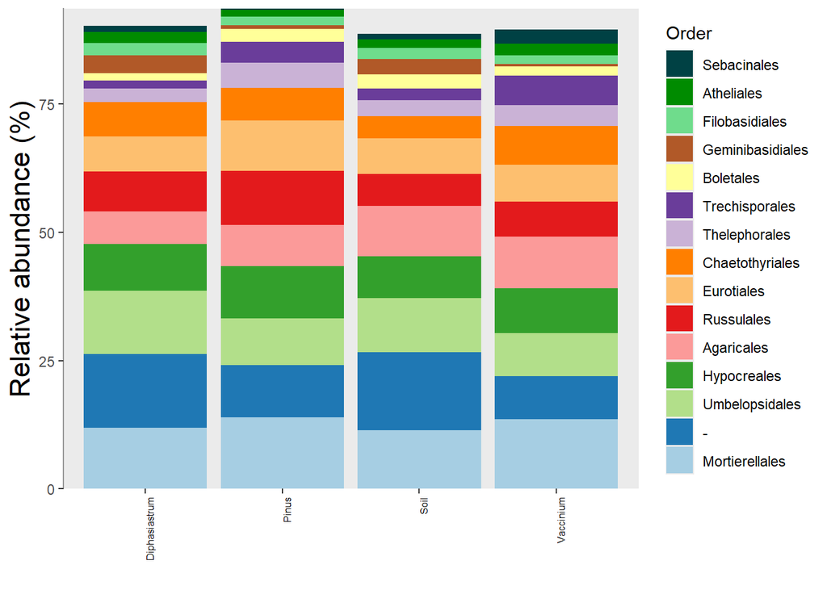

```r
Order <- t1$plot_bar(bar_full = FALSE,xtext_keep = TRUE, xtext_angle = 90,xtext_size = 6, color_values = mycol)
Order
```

“-” = not determined

### Class: Per sample type (15 most abundant)

```r
t1 <- trans_abund$new(dataset = meco_fungi, taxrank = "Class", ntaxa = 15, groupmean = "Species")
```

```
## Species column is used to calculate mean abundance ...
```

```
## The transformed abundance data is stored in object$data_abund ...
```

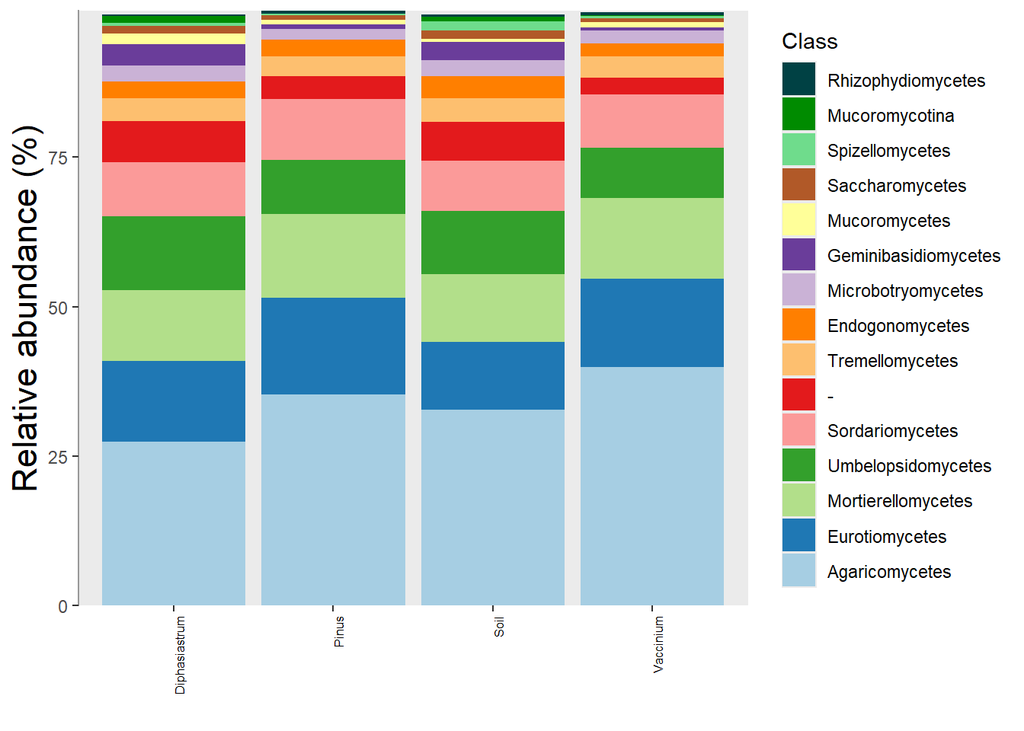

```r
Class <- t1$plot_bar(bar_full = FALSE, xtext_keep = TRUE, xtext_angle = 90, xtext_size = 6, color_values = mycol)
Class
```

“-” = not determined

### Family: Per sample type (15 most abundant)

```r
t1 <- trans_abund$new(dataset = meco_fungi, taxrank = "Family", ntaxa = 15, groupmean = "Species")
```

```
## Species column is used to calculate mean abundance ...
```

```
## The transformed abundance data is stored in object$data_abund ...
```

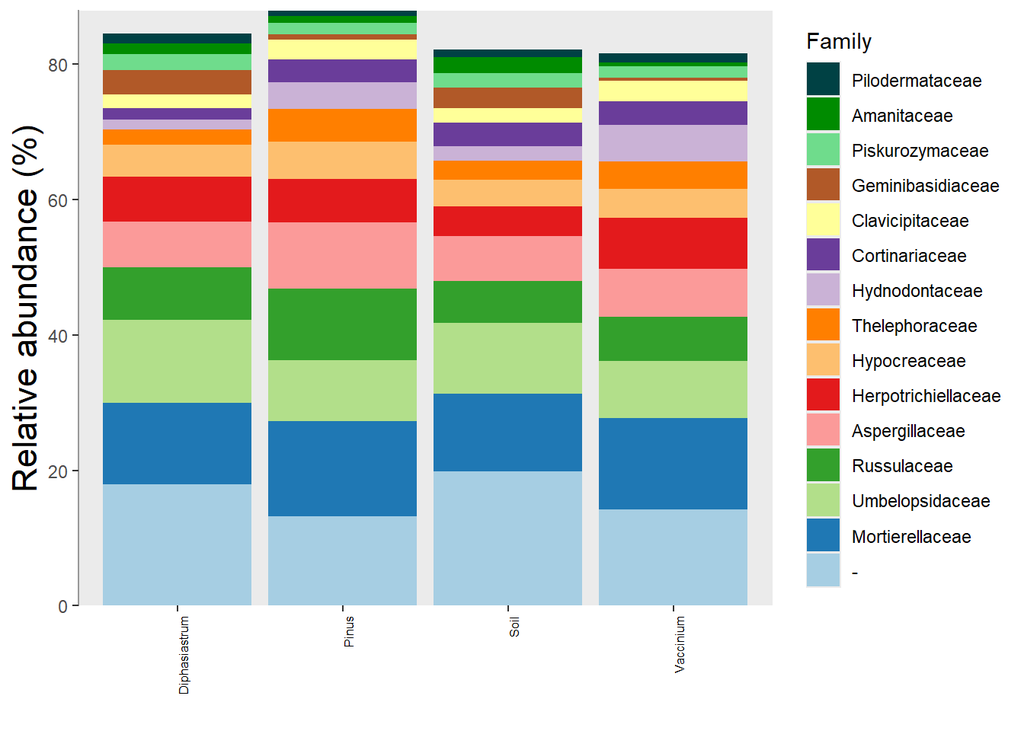

```r
Family<-t1$plot_bar(bar_full = FALSE, xtext_keep = TRUE, xtext_angle = 90,xtext_size = 6, color_values = mycol)
Family
```

“-” = not determined

### Genus: Per sample type (15 most abundant)

```r
t1 <- trans_abund$new(dataset = meco_fungi, taxrank = "Genus", ntaxa = 15, groupmean = "Species")
```

```
## Species column is used to calculate mean abundance ...
```

```
## The transformed abundance data is stored in object$data_abund ...
```

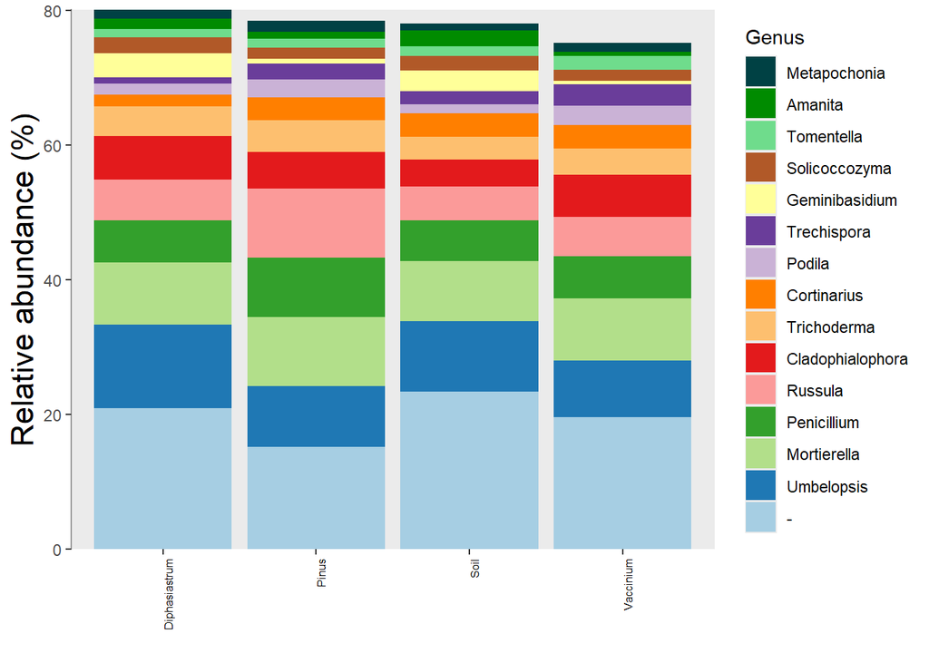

```r
Genus<-t1$plot_bar(bar_full = FALSE, xtext_keep = TRUE, xtext_angle = 90,xtext_size = 6, color_values = mycol)
Genus
```

“-” = not determined

### Species: Per sample type (15 most abundant)

```r
t1 <- trans_abund$new(dataset = meco_fungi, taxrank = "Species", ntaxa = 15,  groupmean = "Species")
```

```
## Species column is used to calculate mean abundance ...
```

```
## The transformed abundance data is stored in object$data_abund ...
```

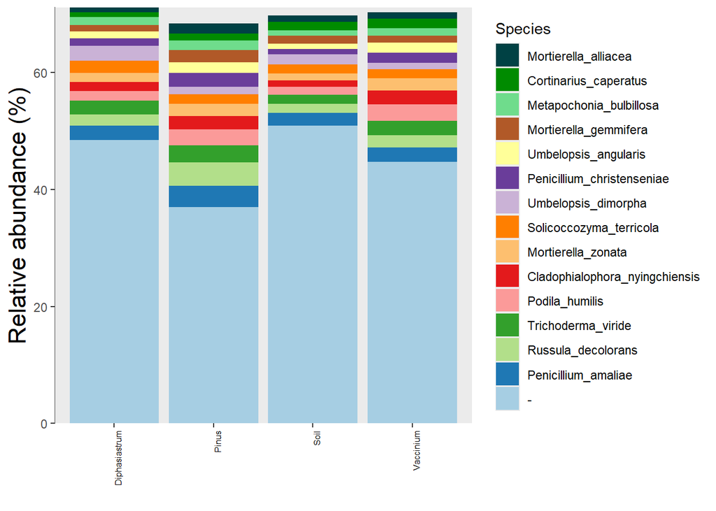

```r
t1$plot_bar(bar_full = FALSE, xtext_keep = TRUE, xtext_angle = 90,xtext_size = 6, color_values = mycol)
```

# Heat tree

## Package “metacoder”

https://grunwaldlab.github.io/metacoder_documentation/workshop--04--manipulating.html

## All taxa, all samples

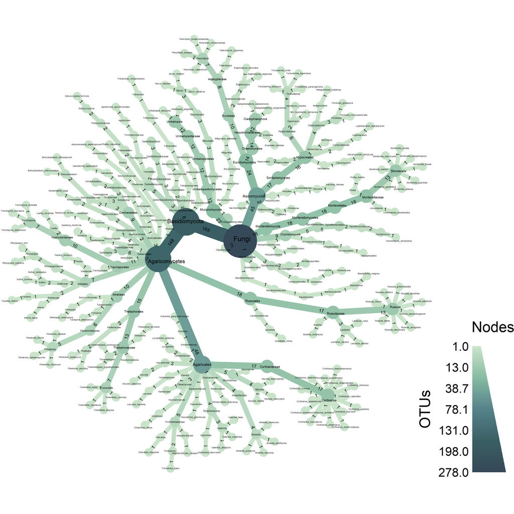

```r
tax_data <-tax_tab
tax_data <- tax_data[tax_data$OTU %in% rownames(filt_count_tab), ] # delete the blank OTUs

counts_norm_df2<-counts_norm_df
row_names <- rownames(counts_norm_df)
rownames(counts_norm_df2) <- NULL
df <- cbind(OTU= row_names, counts_norm_df2) # Add row names as the first column

# Read sample info without technical replicates
sample_data <-read.table("Sample_Info_noR.txt", sep = "\t", header=T, check.names=F)

# Combine the tables sorting by OTU
Tax_otu_data <- left_join(df, tax_data, by = "OTU" )

#converting to taxmap format
obj <- parse_tax_data(Tax_otu_data,
                      class_cols = "taxonomy",
                      class_sep = ";")

#remove unclassified taxa
obj <- filter_taxa(obj, taxon_names != "-")

set.seed(50)
heattree<-heat_tree(obj, node_label = gsub(pattern = "\\[|\\]", replacement = "", taxon_names),
            node_size = n_obs,
            node_size_range = c(0.01, 0.04),
            node_color = n_obs,
            node_color_range = c("#C9E4CA", "#87BBA2", "#55828B", "#3B6064", "#364958"),
            edge_label = n_obs,
            edge_label_size = 0.02,
            node_label_size_range = c(0.005, 0.015),
            node_color_axis_label = "OTUs",
            layout = "davidson-harel", initial_layout = "reingold-tilford")

plot(heattree)
```

## Comparison of sample types (all OTUs)

```r
tax_data <-tax_tab
tax_data <- tax_data[tax_data$OTU %in% rownames(filt_count_tab), ] # delete the blank OTUs

counts_norm_df2<-counts_norm_df
rownames(counts_norm_df2) <- NULL
df <- cbind(OTU= row_names, counts_norm_df2) # Add row names as the first column

sample_data <-read.table("Sample_Info_noR.txt", sep = "\t", header=T, check.names=F)

# Combine the tables sorting by OTU
Tax_otu_data <- left_join(df, tax_data, by = "OTU" )
Tax_otu_data  <- subset(Tax_otu_data , select = -grep("_", names(Tax_otu_data ))) #delete technical replicates


#converting to taxmap format
obj <- parse_tax_data(Tax_otu_data,
                      class_cols = "taxonomy", # The column in the input table
                      class_sep = ";") # What each taxon is separated by

#remove  "-" (unclassified taxa):
obj <- filter_taxa(obj, taxon_names != "-")

#For the heat tree comparison of abundances
obj$data$tax_abund <- calc_taxon_abund(obj, "tax_data", cols = sample_data$Sample)
```

```
## Summing per-taxon counts from 76 columns for 341 taxa
```

```r
obj$data$tax_occ <- calc_n_samples(obj, "tax_abund", groups = sample_data$Species, cols = sample_data$Sample)
```

```
## Calculating number of samples with a value greater than 0 for 76 columns in 4 groups for 341 observations
```

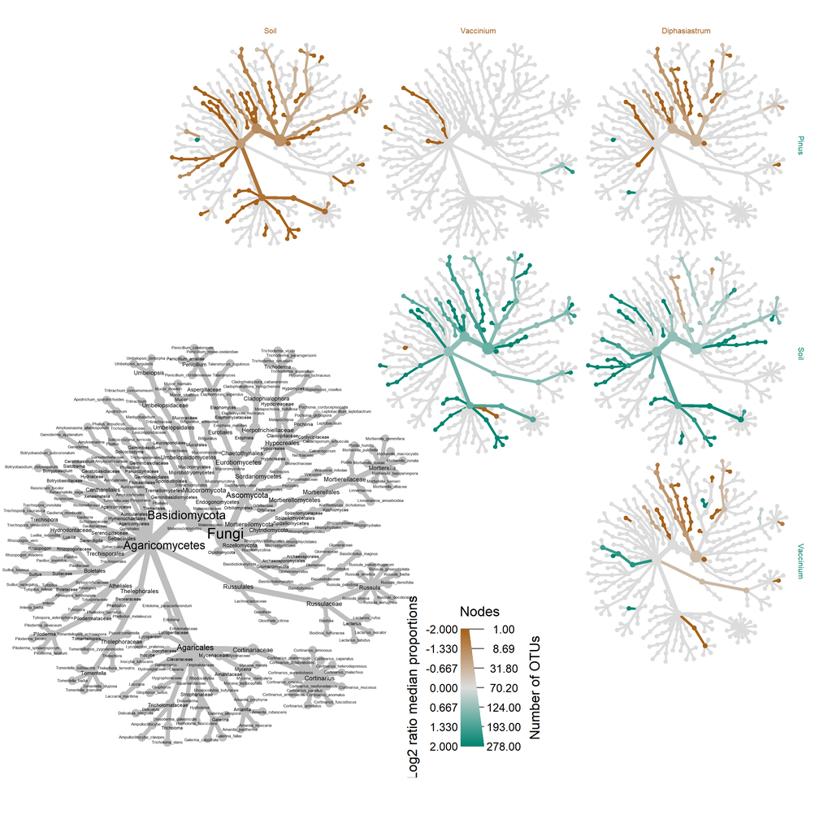

```r
obj$data$diff_table <- compare_groups(obj, data= "tax_abund",
                                      cols = sample_data$Sample, # What columns of sample data to use
                                      groups = sample_data$Species) # What category each sample is assigned to

#We then need to correct for multiple comparisons and set non-significant differences to zero:
obj <- mutate_obs(obj, "diff_table",
                  wilcox_p_value = p.adjust(wilcox_p_value, method = "fdr")) #false discovery rate
obj$data$diff_table$log2_median_ratio[obj$data$diff_table$wilcox_p_value > 0.05] <- 0


set.seed(50)
heattree<-heat_tree_matrix(obj, key_size = 0.65,
                 data = "diff_table",
                 node_size = n_obs, # the number of OTUs per taxon
                 node_label_size_range = c(0.01, 0.035),
                 node_label = taxon_names,
                 node_color = log2_median_ratio,
                 node_color_range = diverging_palette(),
                 node_color_trans = "linear",
                 node_color_interval = c(-2, 2), # The range of `log2_median_ratio`
                 edge_color_interval = c(-2, 2), # The range of `log2_median_ratio`
                 node_size_axis_label = "Number of OTUs",
                 node_color_axis_label = "Log2 ratio median proportions",
                 layout = "davidson-harel", # The primary layout algorithm
                 initial_layout = "reingold-tilford") # The layout algorithm that initializes node locations

plot(heattree)
```

## Comparison of sample types (minimum 2 OTUs per taxon)

```r
tax_data <-tax_tab
tax_data <- tax_data[tax_data$OTU %in% rownames(filt_count_tab), ] # delete the blank OTUs

counts_norm_df2<-counts_norm_df
rownames(counts_norm_df2) <- NULL
df <- cbind(OTU= row_names, counts_norm_df2) # Add row names as the first column

sample_data <-read.table("Sample_Info_noR.txt", sep = "\t", header=T, check.names=F)

# Combine the tables sorting by OTU
Tax_otu_data <- left_join(df, tax_data, by = "OTU" )
Tax_otu_data  <- subset(Tax_otu_data , select = -grep("_", names(Tax_otu_data ))) #delete technical replicates


#converting to taxmap format
obj <- parse_tax_data(Tax_otu_data,
                      class_cols = "taxonomy", # The column in the input table
                      class_sep = ";") # What each taxon is separated by

#remove  "-" (unclassified taxa) and rare taxa:
obj <- filter_taxa(obj, taxon_names != "-")
obj <- filter_taxa(obj, n_obs > 1)


#For the heat tree comparison of abundances
obj$data$tax_abund <- calc_taxon_abund(obj, "tax_data", cols = sample_data$Sample)
```

```
## Summing per-taxon counts from 76 columns for 118 taxa
```

```r
obj$data$tax_occ <- calc_n_samples(obj, "tax_abund", groups = sample_data$Species, cols = sample_data$Sample)
```

```
## Calculating number of samples with a value greater than 0 for 76 columns in 4 groups for 118 observations
```

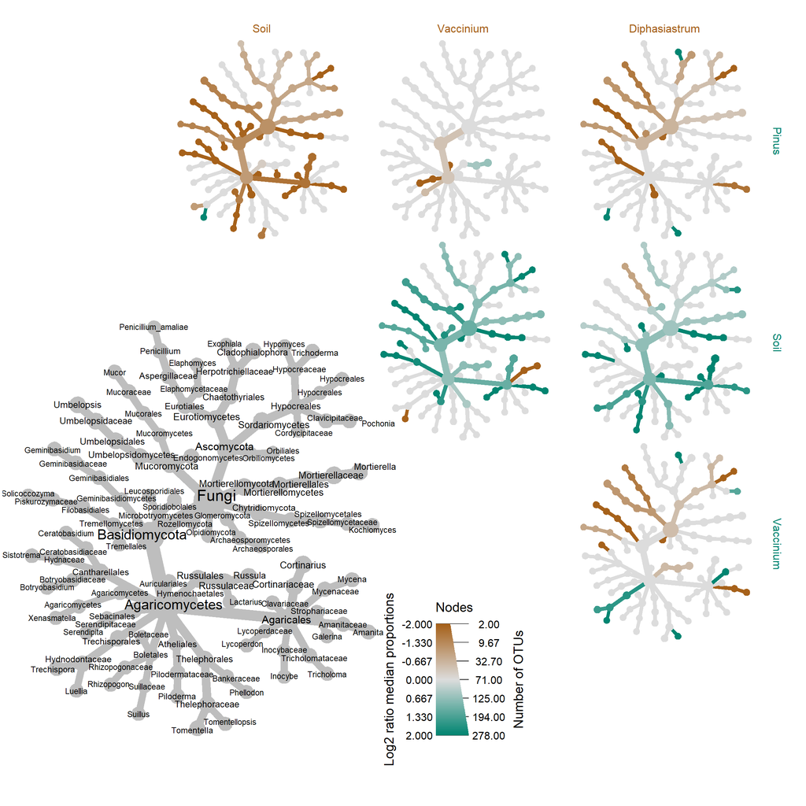

```r
obj$data$diff_table <- compare_groups(obj, data= "tax_abund",
                                      cols = sample_data$Sample, # What columns of sample data to use
                                      groups = sample_data$Species) # What category each sample is assigned to

#We then need to correct for multiple comparisons and set non-significant differences to zero:
obj <- mutate_obs(obj, "diff_table",
                  wilcox_p_value = p.adjust(wilcox_p_value, method = "fdr")) #false discovery rate
obj$data$diff_table$log2_median_ratio[obj$data$diff_table$wilcox_p_value > 0.05] <- 0

set.seed(50)
heattree<-heat_tree_matrix(obj, key_size = 0.65,
                 data = "diff_table",
                 node_size = n_obs, # the number of OTUs per taxon
                 node_label_size_range = c(0.02, 0.04),
                 node_label = taxon_names,
                 node_color = log2_median_ratio,
                 node_color_range = diverging_palette(),
                 node_color_trans = "linear",
                 node_color_interval = c(-2, 2), # The range of `log2_median_ratio`
                 edge_color_interval = c(-2, 2), # The range of `log2_median_ratio`
                 node_size_axis_label = "Number of OTUs",
                 node_color_axis_label = "Log2 ratio median proportions",
                 layout = "davidson-harel", # The primary layout algorithm
                 initial_layout = "reingold-tilford") # The layout algorithm that initializes node locations

plot(heattree)
```

# iNEXT package - diversity indices

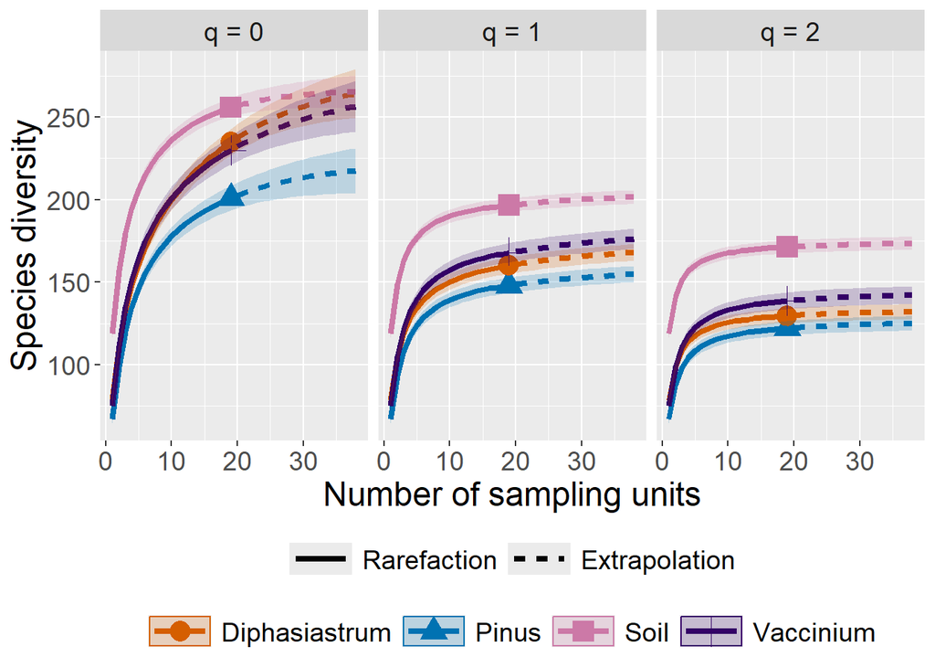

```r
# I used normalized counts after NTCs treatments and without technical replicates
count_tab <- counts_norm_df[, unlist(lapply(counts_norm_df, is.numeric))]
row.names(count_tab) <- count_tab$OTU.ID
count_tab <- subset(count_tab, select = -grep("_", names(count_tab))) #delete technical replicates
count_tab <- count_tab > 0

# get OTU incidence data for all plots separately
inc_P <- count_tab[,grepl("P", colnames(count_tab))]
inc_D <- count_tab[,grepl("D", colnames(count_tab))]
inc_V <- count_tab[,grepl("V", colnames(count_tab))]
inc_S <- count_tab[,grepl("S", colnames(count_tab))]

# create a dataframe with incidence data summed by rows within plots
inc_byspecies <- cbind(rowSums(inc_P), rowSums(inc_D), rowSums(inc_V),
                    rowSums(inc_S))

colnames(inc_byspecies) <- c("Pinus", "Diphasiastrum", "Vaccinium", "Soil")

inc_byspecies <- rbind(c(length(colnames(inc_P)),
                      length(colnames(inc_D)),
                      length(colnames(inc_V)),
                      length(colnames(inc_S))), inc_byspecies)

inc_byspecies<-as.data.frame(inc_byspecies)


# Get the diversity estimates
out <- iNEXT(inc_byspecies, q=c(0,1,2), datatype ="incidence_freq", se = TRUE)

# Plot the diversity estimates

# Sample-size-based rarefaction and extrapolation (R/E) curve (type=1). This curve plots diversity estimates with 95% confidence intervals (if se=TRUE) as a function of sample size up to double the reference sample size, by default, or a user‐specified endpoint:

ggiNEXT(out, type=1, facet.var="Order.q", se = TRUE, color.var="Assemblage")
```

Hill number = effective number of species/OTUs. Hill numbers determines the measures’ sensitivity to species/OTUs relative abundances. Hill numbers include the three most widely used species diversity measures as special cases: species richness (q = 0), Shannon diversity (q = 1, as the effective number of common species/OTUs in the assemblage) and Simpson diversity (q = 2, effective number of dominant species/OTUs in the assemblage)

## Sample completeness curve

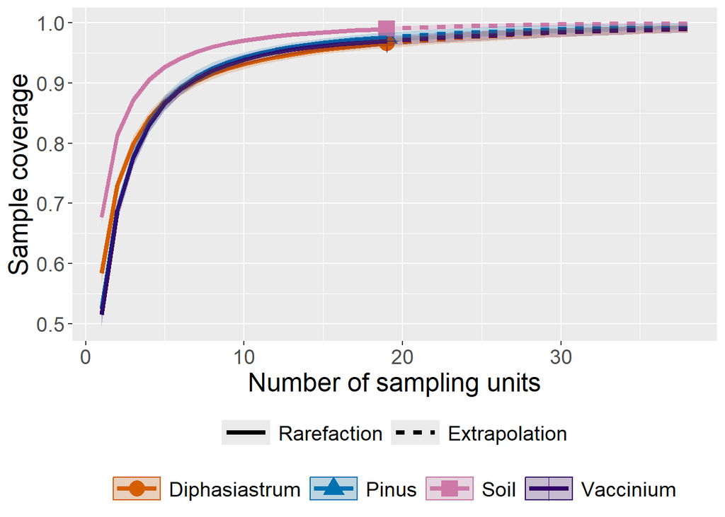

```r
ggiNEXT(out, type=2, facet.var="None", color.var="Assemblage", se = TRUE)
```

Sample completeness curve (type=2) with confidence intervals (if se=TRUE): see Figs. 1b and 2b in Hsieh et al. (2016). This curve plots the sample coverage with respect to sample size for the same range described in (1).

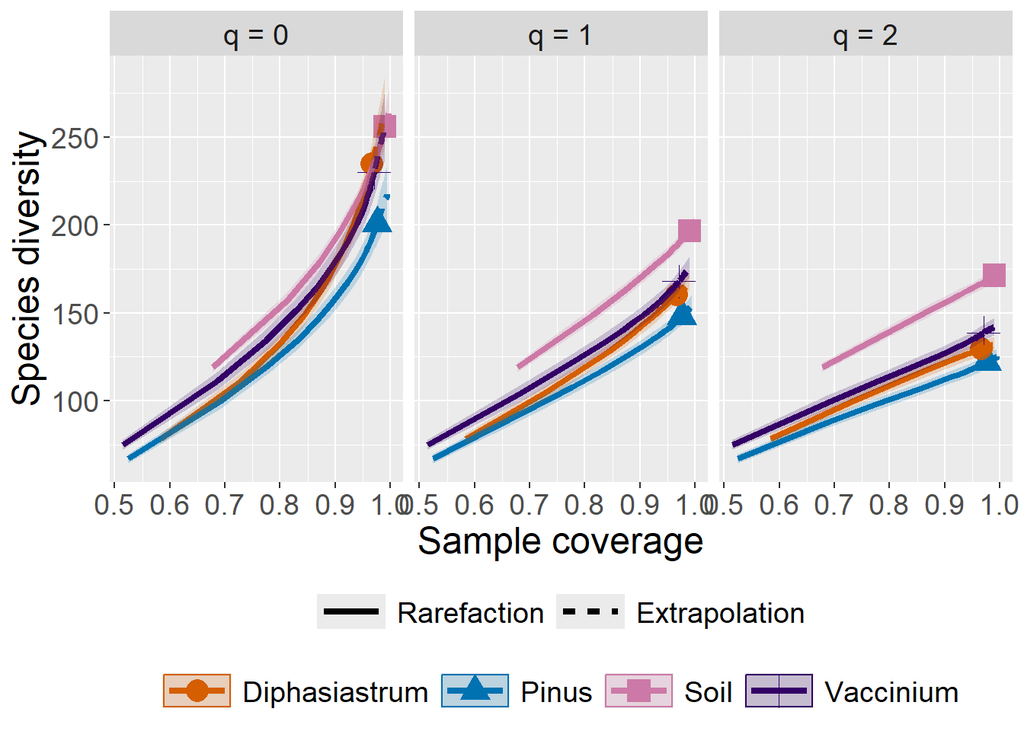

```r
ggiNEXT(out, type=3, facet.var="Order.q", color.var="Assemblage", se =TRUE)
```

Coverage-based R/E curve (type=3): see Figs. 1c and 2c in Hsieh et al. (2016). This curve plots the diversity estimates with confidence intervals (if se=TRUE) as a function of sample coverage up to the maximum coverage obtained from the maximum size described in (1)

## Diversity indices (only Ectomycorrhizal OTUs)

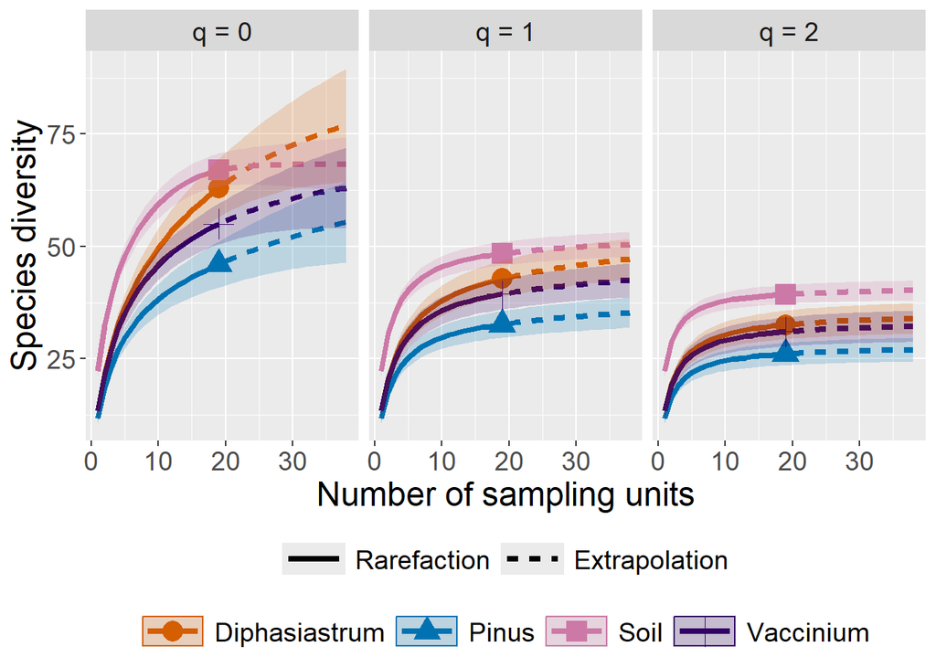

```r
# select only ECM OTUs:
matching_rows <- tax_tab$OTU[tax_tab$Guild %in% c("Ectomycorrhizal")]

# Subset the matrix based on the matching row names
filtered_vs_trans_count_tab <- vst_trans_count_tab[matching_rows, ]
Symbio_df <- as.data.frame(filtered_vs_trans_count_tab)

#I used normalized counts of reads after removing of OTUs found in NTCs and technical replicates
count_tab <- Symbio_df[, unlist(lapply(Symbio_df, is.numeric))]
row.names(count_tab) <- count_tab$OTU.ID
count_tab <- subset(count_tab, select = -grep("_", names(count_tab))) #delete technical replicates
count_tab <- count_tab > 0

inc_P <- count_tab[,grepl("P", colnames(count_tab))] # get OTU incidence data for all plots separately
inc_D <- count_tab[,grepl("D", colnames(count_tab))]
inc_V <- count_tab[,grepl("V", colnames(count_tab))]
inc_S <- count_tab[,grepl("S", colnames(count_tab))]

# create a dataframe with incidence data summed by rows within plots
inc_byspecies <- cbind(rowSums(inc_P), rowSums(inc_D), rowSums(inc_V),
                    rowSums(inc_S))

colnames(inc_byspecies) <- c("Pinus", "Diphasiastrum", "Vaccinium", "Soil")

inc_byspecies <- rbind(c(length(colnames(inc_P)),
                      length(colnames(inc_D)),
                      length(colnames(inc_V)),
                      length(colnames(inc_S))), inc_byspecies)

inc_byspecies<-as.data.frame(inc_byspecies)

# Get the diversity estimates
out <- iNEXT(inc_byspecies, q=c(0,1,2), datatype ="incidence_freq", se = TRUE)

# Plot the diversity estimates
ggiNEXT(out, type=1, facet.var="Order.q", se = TRUE, color.var="Assemblage")
```

Sample-size-based rarefaction and extrapolation (R/E) curve (type=1). This curve plots diversity estimates with 95% confidence intervals (if se=TRUE) as a function of sample size up to double the reference sample size, by default, or a user‐specified endpoint:

## Sample completeness curve

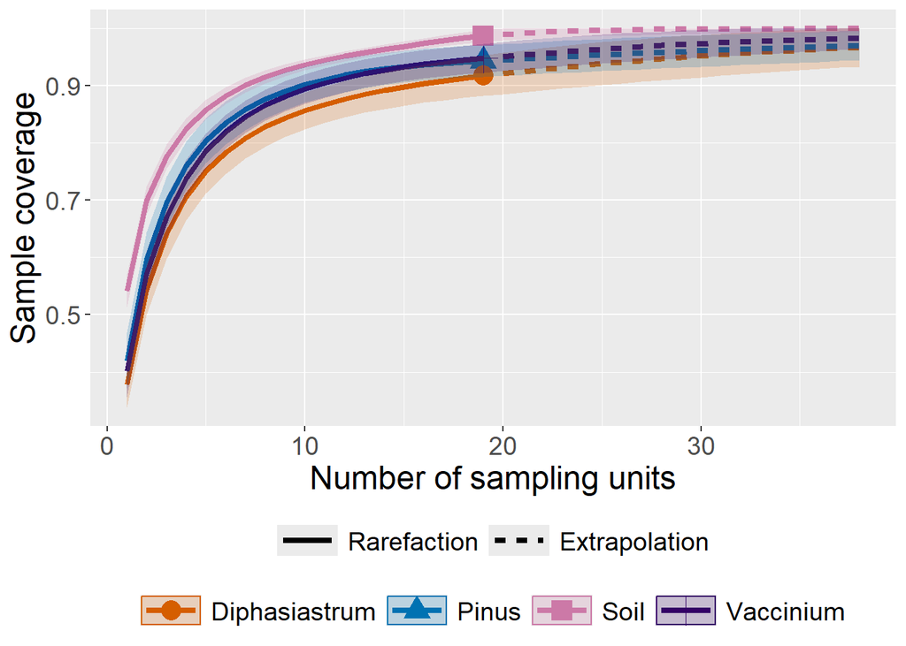

```r
ggiNEXT(out, type=2, facet.var="None", color.var="Assemblage", se = TRUE)
```

## Trophic Mode (FunGuild database)

```r
#read info table with the samples without replicates
sample_info_no_rep <- read.table("Sample_Info_noR.txt", header=T, row.names=1, check.names=F)

tax_table<-tax_tab
row.names(tax_table) <- tax_table$OTU
tax_table <- tax_table[, -1]
tax_table<- tax_table[order(rownames(tax_table)),]

# create a data frame from normalized dataset
counts_norm_df<-as.data.frame(vst_trans_count_tab)
row_names <- rownames(counts_norm_df)
counts_norm_df <-as.data.frame(counts_norm_df)
rownames(counts_norm_df) <- row_names

# create microeco file
meco_fungi <- microtable$new(sample_table = sample_info_no_rep, otu_table = counts_norm_df, tax_table = tax_table)

t1t <- trans_abund$new(dataset = meco_fungi, taxrank = "Trophic_Mode", ntaxa = 10)
```

```
## No taxa_abund list found. Calculate relative abundance with cal_abund function ...
```

```
## The result is stored in object$taxa_abund ...
```

```
## The transformed abundance data is stored in object$data_abund ...
```

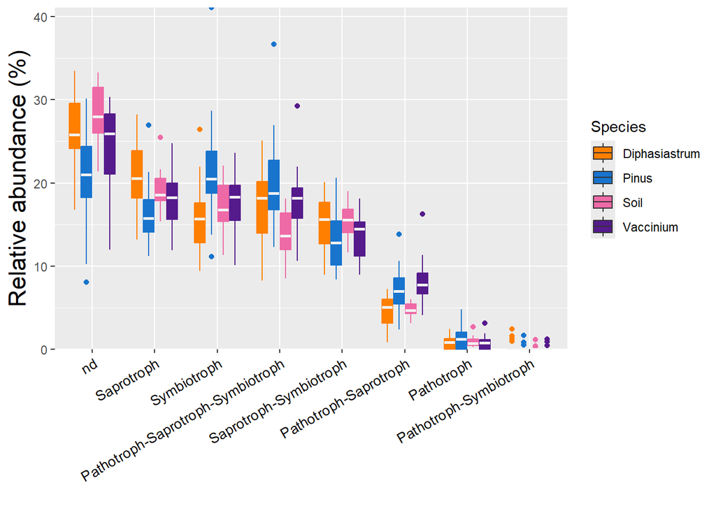

```r
scolor<-c("darkorange1","dodgerblue3","hotpink2", "purple4")
Trophic_Mode <- t1t$plot_box(group = "Species", xtext_angle = 30, color_values = scolor) + ylab("Relative abundance (%)")
Trophic_Mode
```

## Statistical comparison of Saprotrophic OTUs abundancy

```r
abund_t<-t1t$data_abund

shapiro.test(abund_t[abund_t$Taxonomy == "Saprotroph",]$Abundance) # data normally distributed
```

```
##
##  Shapiro-Wilk normality test
##
## data:  abund_t[abund_t$Taxonomy == "Saprotroph", ]$Abundance
## W = 0.98623, p-value = 0.5848
```

```r
bartlett.test(Abundance ~ Species, abund_t[abund_t$Taxonomy == "Saprotroph",]) # variances are equal
```

```
##
##  Bartlett test of homogeneity of variances
##
## data:  Abundance by Species
## Bartlett's K-squared = 5.5208, df = 3, p-value = 0.1374
```

```r
TukeySapro <- TukeyHSD(aov(Abundance ~ Species, abund_t[abund_t$Taxonomy == "Saprotroph",]))
TukeySapro
```

```
##   Tukey multiple comparisons of means
##     95% family-wise confidence level
##
## Fit: aov(formula = Abundance ~ Species, data = abund_t[abund_t$Taxonomy == "Saprotroph", ])
##
## $Species
##                              diff        lwr        upr     p adj
## Pinus-Diphasiastrum     -4.043536 -6.9354675 -1.1516037 0.0024935
## Soil-Diphasiastrum      -1.281917 -4.1738493  1.6100145 0.6501675
## Vaccinium-Diphasiastrum -2.397722 -5.2896541  0.4942098 0.1384604
## Soil-Pinus               2.761618 -0.1303138  5.6535501 0.0665675
## Vaccinium-Pinus          1.645813 -1.2461185  4.5377454 0.4447497
## Vaccinium-Soil          -1.115805 -4.0077367  1.7761272 0.7413522
```

## Statistical comparison of Symbiotroph abundancy

```r
abund_t<-t1t$data_abund

shapiro.test(abund_t[abund_t$Taxonomy == "Symbiotroph",]$Abundance) # data not normally distributed
```

```
##
##  Shapiro-Wilk normality test
##
## data:  abund_t[abund_t$Taxonomy == "Symbiotroph", ]$Abundance
## W = 0.92837, p-value = 0.0003521
```

```r
bartlett.test(Abundance ~ Species, abund_t[abund_t$Taxonomy == "Symbiotroph",]) # variances are not equal
```

```
##
##  Bartlett test of homogeneity of variances
##
## data:  Abundance by Species
## Bartlett's K-squared = 9.9411, df = 3, p-value = 0.01907
```

```r
kruskal_effsize(abund_t[abund_t$Taxonomy == "Symbiotroph",], Abundance ~ Species )
```

```
## # A tibble: 1 × 5
##   .y.           n effsize method  magnitude
## * <chr>     <int>   <dbl> <chr>   <ord>
## 1 Abundance    76   0.172 eta2[H] large
```

```r
res.kruskal <-kruskal_test(abund_t[abund_t$Taxonomy == "Symbiotroph",], Abundance ~ Species)
res.kruskal
```

```
## # A tibble: 1 × 6
##   .y.           n statistic    df       p method
## * <chr>     <int>     <dbl> <int>   <dbl> <chr>
## 1 Abundance    76      15.4     3 0.00153 Kruskal-Wallis
```

```r
pwc<-dunn_test(abund_t[abund_t$Taxonomy == "Symbiotroph",], Abundance ~ Species, p.adjust.method = "bonferroni")
pwc
```

```
## # A tibble: 6 × 9
##   .y.       group1     group2    n1    n2 statistic       p   p.adj p.adj.signif
## * <chr>     <chr>      <chr>  <int> <int>     <dbl>   <dbl>   <dbl> <chr>
## 1 Abundance Diphasias… Pinus     19    19     3.86  1.12e-4 6.69e-4 ***
## 2 Abundance Diphasias… Soil      19    19     1.37  1.70e-1 1   e+0 ns
## 3 Abundance Diphasias… Vacci…    19    19     1.65  9.84e-2 5.90e-1 ns
## 4 Abundance Pinus      Soil      19    19    -2.49  1.28e-2 7.66e-2 ns
## 5 Abundance Pinus      Vacci…    19    19    -2.21  2.70e-2 1.62e-1 ns
## 6 Abundance Soil       Vacci…    19    19     0.279 7.80e-1 1   e+0 ns
```

## Guild (FunGuild database)

```r
#read info table with the samples without replicates
sample_info_no_rep <- read.table("Sample_Info_noR.txt", header=T, row.names=1, check.names=F)

tax_table<-tax_tab
row.names(tax_table) <- tax_table$OTU
tax_table <- tax_table[, -1]
tax_table<- tax_table[order(rownames(tax_table)),]

# create a data frame from normalized data
counts_norm_df<-as.data.frame(vst_trans_count_tab)
row_names <- rownames(counts_norm_df)
counts_norm_df <-as.data.frame(counts_norm_df)
rownames(counts_norm_df) <- row_names

# create microeco file
meco_fungi <- microtable$new(sample_table = sample_info_no_rep, otu_table = counts_norm_df, tax_table = tax_table)

t1 <- trans_abund$new(dataset = meco_fungi, taxrank = "Guild", ntaxa = 15)
```

```
## No taxa_abund list found. Calculate relative abundance with cal_abund function ...
```

```
## The result is stored in object$taxa_abund ...
```

```
## The transformed abundance data is stored in object$data_abund ...
```

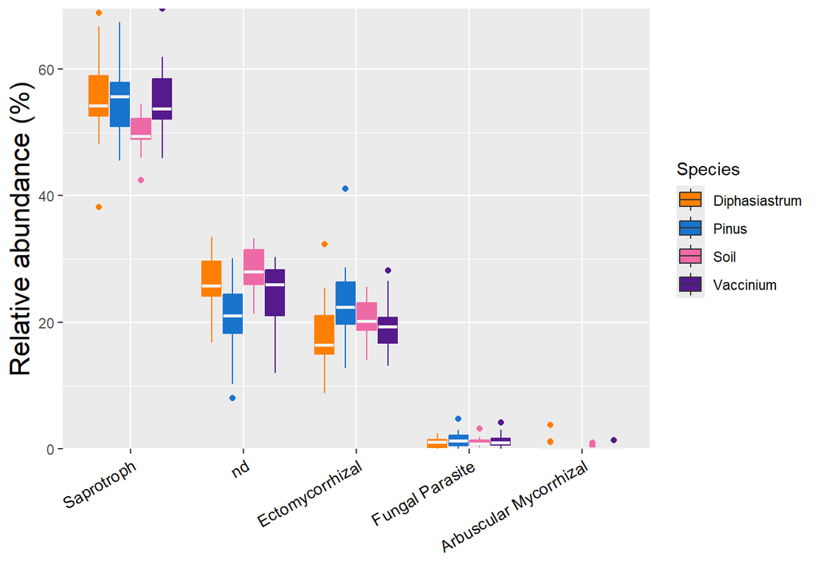

```r
Guilds <- t1$plot_box(group = "Species", xtext_angle = 30, color_values = scolor) + ylab("Relative abundance (%)")
Guilds
```

## Statistical comparison of Ectomycorrhizal OTUs abundancy

```r
abund<-t1$data_abund

shapiro.test(abund[abund$Taxonomy == "Ectomycorrhizal",]$Abundance) # data not normally distributed
```

```
##
##  Shapiro-Wilk normality test
##
## data:  abund[abund$Taxonomy == "Ectomycorrhizal", ]$Abundance
## W = 0.96117, p-value = 0.02019
```

```r
bartlett.test(Abundance ~ Species, abund[abund$Taxonomy == "Ectomycorrhizal",]) # variances are not equal
```

```
##
##  Bartlett test of homogeneity of variances
##
## data:  Abundance by Species
## Bartlett's K-squared = 11.005, df = 3, p-value = 0.0117
```

```r
kruskal_effsize(abund[abund$Taxonomy == "Ectomycorrhizal",], Abundance ~ Species )
```

```
## # A tibble: 1 × 5
##   .y.           n effsize method  magnitude
## * <chr>     <int>   <dbl> <chr>   <ord>
## 1 Abundance    76   0.101 eta2[H] moderate
```

```r
res.kruskal <-kruskal_test(abund[abund$Taxonomy == "Ectomycorrhizal",], Abundance ~ Species)
res.kruskal
```

```
## # A tibble: 1 × 6
##   .y.           n statistic    df      p method
## * <chr>     <int>     <dbl> <int>  <dbl> <chr>
## 1 Abundance    76      10.3     3 0.0162 Kruskal-Wallis
```

```r
pwc<-dunn_test(abund[abund$Taxonomy == "Ectomycorrhizal",], Abundance ~ Species, p.adjust.method = "bonferroni")
pwc
```

```
## # A tibble: 6 × 9
##   .y.       group1      group2    n1    n2 statistic       p  p.adj p.adj.signif
## * <chr>     <chr>       <chr>  <int> <int>     <dbl>   <dbl>  <dbl> <chr>
## 1 Abundance Diphasiast… Pinus     19    19     3.13  0.00175 0.0105 *
## 2 Abundance Diphasiast… Soil      19    19     1.88  0.0600  0.360  ns
## 3 Abundance Diphasiast… Vacci…    19    19     1.18  0.240   1      ns
## 4 Abundance Pinus       Soil      19    19    -1.25  0.212   1      ns
## 5 Abundance Pinus       Vacci…    19    19    -1.95  0.0507  0.304  ns
## 6 Abundance Soil        Vacci…    19    19    -0.705 0.481   1      ns
```

-> Pinus has more ECM than Diphasiastrum